# Tala data science challenge problem

We can also plot the boxplots for each attribute to see their range of variations.

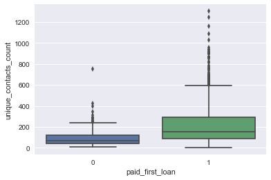

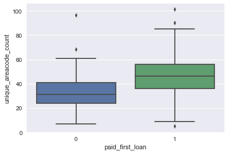

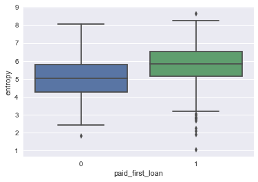

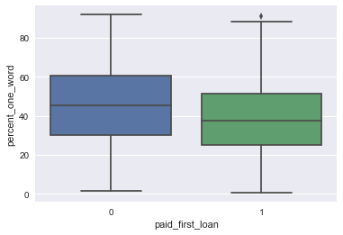

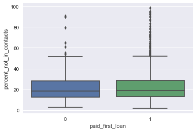

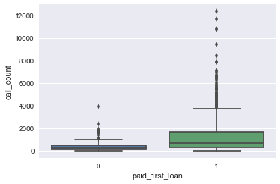

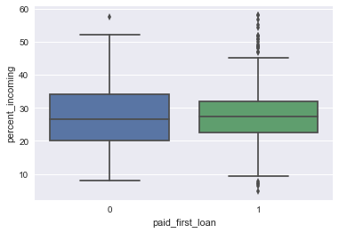

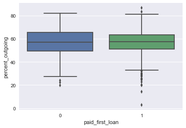

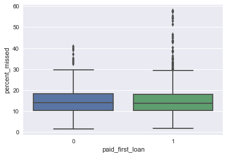

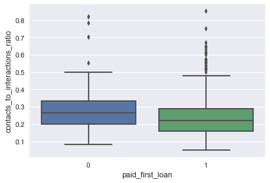

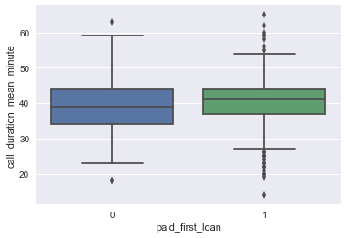

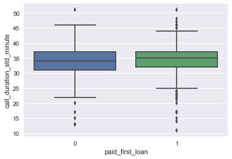

[5 more figures not shown]

```python
for column_index, column in enumerate(loan_data.columns):
    if column == 'paid_first_loan':
        continue
    sb.boxplot(x='paid_first_loan', y=column, data=loan_data)
    plt.figure()
```

### Classification model

[ go back to the top ]

Load data and drop the person_ID attribute. Then transform the dataframe to numpy array and do median imputation to fill missing values.

```python
loan_data = pd.read_csv("./call_loan.csv")
loan_data.drop(['person_id_random'], axis=1, inplace=True)
list_of_attributes = loan_data.columns.values.tolist()[:-1]
```

```python
all_inputs = loan_data.drop(['paid_first_loan'], axis=1).values
all_classes = loan_data.paid_first_loan.values
```

```python
imp = Imputer(missing_values='NaN', strategy='median', axis=0)
all_inputs = imp.fit_transform(all_inputs)
```

Here, we need to discretize nonmonotonic variables. We use qcut function from pandas in order to discretize each variable to 10 quantiles. Then, we use LabelEncoder class from sklearn to assign labels to each segment of the discretized variables.

```python
list_to_discretize = ['percent_incoming', 'percent_outgoing', 'percent_missed', 'call_duration_mean_minute',
                      'call_duration_std_minute', 'percent_nightcalls_duration', 'percent_businesshours_calls_duration',
                      'inter_event_duration_mean_minute', 'inter_event_duration_std_minute',
                      'days_from_signup_to_disbursement']

# convert the imputed array of inputs to dataframe to be able to use the pd.qcut method and disretize some columns
all_inputs = pd.DataFrame(all_inputs, columns=list_of_attributes)

# use labelencoder to discretize and transform non-monotonic columns
le = LabelEncoder()
for index, column in enumerate(list_to_discretize):
    all_inputs[column] = pd.qcut(all_inputs[column], 10, duplicates='drop').astype('category')
    all_inputs[column] = le.fit_transform(all_inputs[column].tolist())

# convert the dataframe to array
all_inputs = all_inputs.values
```

```python
all_inputs
```

```
array([[ 662.  ,   67.  ,    7.69, ...,    0.  ,    3.  ,    4.  ],
       [ 194.  ,   53.  ,    5.57, ...,    4.  ,    6.  ,    5.  ],
       [ 165.  ,   53.  ,    5.89, ...,    6.  ,    6.  ,    1.  ],
       ...,
       [  93.  ,   34.  ,    5.41, ...,    8.  ,    9.  ,    0.  ],
       [ 269.  ,   56.  ,    6.06, ...,    0.  ,    1.  ,    0.  ],
       [  42.  ,   29.  ,    4.69, ...,    5.  ,    2.  ,    1.  ]])
```

The first classifier that we train is the random forest. We use randomized search instead of grid search to have higher computation speeds and search over parameters spacem specifically the nu,ber of trees in the forest and size of each tree. We use AUC score to report the performance of the classifier. Finally we use all the data to fit the classifier with the best hyperparameters found via cross validated randomized search.

```python
random_forest_classifier = RandomForestClassifier()

parameters_rf = {'n_estimators': [5, 10, 25, 50, 70, 100],
                 'min_samples_split': range(2, 20),
                 'criterion': ['gini', 'entropy'],
                 'bootstrap': [True, False]
                }

n_iter_search = 50
random_search_rf = RandomizedSearchCV(random_forest_classifier,
                                      param_distributions=parameters_rf,
                                      scoring='roc_auc',
                                      cv=10)

start = time()
random_search_rf.fit(all_inputs, all_classes)
print("RandomizedSearchCV for random forest took %.2f seconds for %d candidates"
      " parameter settings." % ((time() - start), n_iter_search))
print('Best roc_auc score of the RandomForest model using Randomized search is: {}'.format(random_search_rf.best_score_))
print('Best parameters of the RandomForest model using Randomized search are: {}'.format(random_search_rf.best_params_))
```

```
RandomizedSearchCV for random forest took 21.45 seconds for 50 candidates parameter settings.
Best roc_auc score of the RandomForest model using Randomized search is: 0.8080027962852677
Best parameters of the RandomForest model using Randomized search are: {'n_estimators': 70, 'min_samples_split': 18, 'criterion': 'entropy', 'bootstrap': True}
```

Now, we have learned the best classifier model and can report the cross validated AUC score for this classifier. We also boxplot the variations of the score.

```
The mean CV AUC score is 0.80 for the RandomForest model
```

```
Text(0.5,1,'Cross-validated AUC score of the Random forest model')
```

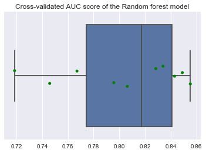

```python
# take the best classifier from the search and use that
random_forest_classifier = random_search_rf.best_estimator_

# Plot cross validated performance of the finally selected RF model
rf_scores = cross_val_score(random_forest_classifier, all_inputs, all_classes, cv=10, scoring='roc_auc')
print('The mean CV AUC score is %.2f for the RandomForest model'% (rf_scores.mean()))

sb.boxplot(rf_scores)
sb.stripplot(rf_scores, jitter=True, color='green').set_title('Cross-validated AUC score of the Random forest model')
```

Randon forest can give us the ranking of the features based on their importance in predicting the class variable. The higher the variables are placed in the trees the more informative they are in predicting the target class.

```python
# Finding the most important features from Randomforest model
importances = random_forest_classifier.feature_importances_
indices = np.argsort(importances)[::-1]
print('Feature ranking by name:')
for f in range(all_inputs.shape[1]):
    print("%d. feature %s (%f)" % (f + 1, list_of_attributes[indices[f]], importances[indices[f]]))
```

```
Feature ranking by name:
1. feature unique_areacode_count (0.123195)
2. feature call_count (0.112709)
3. feature unique_contacts_count (0.092408)
4. feature days_from_signup_to_disbursement (0.089626)
5. feature entropy (0.087783)
6. feature inter_event_duration_std_minute (0.069914)
7. feature percent_one_word (0.063355)
8. feature percent_not_in_contacts (0.058878)
9. feature inter_event_duration_mean_minute (0.057527)
10. feature contacts_to_interactions_ratio (0.047754)
11. feature percent_incoming (0.033431)
12. feature percent_nightcalls_duration (0.033375)
13. feature percent_missed (0.028993)
14. feature percent_businesshours_calls_duration (0.028702)
15. feature call_duration_mean_minute (0.026887)
16. feature call_duration_std_minute (0.024935)
17. feature percent_outgoing (0.020529)
```

```
(-1, 17)
```

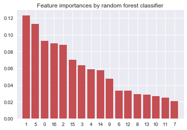

```python
plt.title("Feature importances by random forest classifier")
plt.bar(range(all_inputs.shape[1]), importances[indices],
        color="r", align="center")
plt.xticks(range(all_inputs.shape[1]), indices)
plt.xlim([-1, all_inputs.shape[1]])
```

We repeat the same procedure of randomized search for gradient boosting model. Here we choose to iterate over the number of tree estimators, the loss function, the learning rate, the maximum depth of tree and the percentage of subsamples. Since exponential loss function cover the AdaBoost classifier,we do not consider it separately. Learning rate is the shrinkage factor which controls and shrinks the contribution of each tree. Max depth parameter tunes the size of each tree and subsample parameter introduces extra randomness to the model by picking a subsample of data for training each tree, i.e. stochastic gradient boosting.

The gradient boosting tree is slower than random forest since it is stagewise additive model and the trees are dependent, so they need to be trained sequentially rather than parallel.

```python
gradient_boosting_classifier = GradientBoostingClassifier()

parameters_grd = {'n_estimators': [100, 150, 200],
                  'loss': ['deviance', 'exponential'],
                  'learning_rate': np.arange(0.01, 0.1, 0.03),
                  'max_depth': [2, 4, 6, 8],
                  'subsample': np.arange(0.3, 1, 0.3)}

n_iter_search = 50
random_search_grd = RandomizedSearchCV(gradient_boosting_classifier,
                                       param_distributions=parameters_grd,
                                       scoring='roc_auc',
                                       cv=10)

start = time()
random_search_grd.fit(all_inputs, all_classes)
print('\n')
print("RandomizedSearchCV for gradient boosting took %.2f seconds for %d candidates"
      " parameter settings." % ((time() - start), n_iter_search))
print('Best roc_auc score of the Gradient Boosting model using Randomized search is: {}'.format(
      random_search_grd.best_score_))
print('Best parameters of the Gradient Boosting model using Randomized search are: {}'.format(
      random_search_grd.best_params_))
```

```
RandomizedSearchCV for gradient boosting took 77.38 seconds for 50 candidates parameter settings.
Best roc_auc score of the Gradient Boosting model using Randomized search is: 0.8000535062904788
Best parameters of the Gradient Boosting model using Randomized search are: {'subsample': 0.59999999999999998, 'n_estimators': 150, 'max_depth': 4, 'loss': 'exponential', 'learning_rate': 0.01}
```

Again we plot the variations of 10-fold cross validated AUC score using the best gradient boosting classifier that is learned.

```
The mean CV AUC score is 0.80 for the Gradient Boosting model
```

```
Text(0.5,1,'Cross-validated AUC score of the gradient boosting model')
```

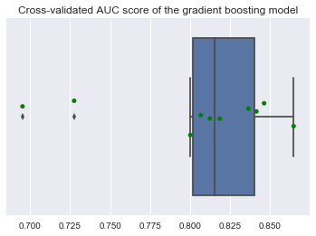

```python
# take the best classifier from the search and use it
gradient_boosting_classifier = random_search_grd.best_estimator_

# Plot cross validated performance of the finally selected GB model
grd_scores = cross_val_score(gradient_boosting_classifier, all_inputs, all_classes, cv=10, scoring='roc_auc')
print('The mean CV AUC score is %.2f for the Gradient Boosting model' % (grd_scores.mean()))

sb.boxplot(grd_scores)
sb.stripplot(grd_scores, jitter=True, color='green').set_title('Cross-validated AUC score of the gradient boosting model')
```

```python
# Finding the most important features from Gradient boosting model
importances = gradient_boosting_classifier.feature_importances_
indices = np.argsort(importances)[::-1]
print('\n')
print('Feature ranking by name:')
for f in range(all_inputs.shape[1]):
    print("%d. feature %s (%f)" % (f + 1, list_of_attributes[indices[f]], importances[indices[f]]))
```

```
Feature ranking by name:
1. feature unique_areacode_count (0.216356)
2. feature days_from_signup_to_disbursement (0.161102)
3. feature call_count (0.082055)
4. feature inter_event_duration_std_minute (0.070534)
5. feature entropy (0.066908)
6. feature percent_one_word (0.065645)
7. feature inter_event_duration_mean_minute (0.063731)
8. feature unique_contacts_count (0.056448)
9. feature percent_not_in_contacts (0.054344)
10. feature percent_nightcalls_duration (0.030460)
11. feature contacts_to_interactions_ratio (0.028674)
12. feature percent_incoming (0.022722)
13. feature call_duration_mean_minute (0.019138)
14. feature call_duration_std_minute (0.018153)
15. feature percent_missed (0.017628)
16. feature percent_businesshours_calls_duration (0.016057)
17. feature percent_outgoing (0.010046)
```

```
(-1, 17)
```

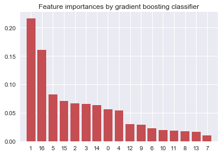

```python
# Plot the feature importances of the gradient boosting
plt.figure()
plt.title("Feature importances by gradient boosting classifier")
plt.bar(range(all_inputs.shape[1]), importances[indices],
        color="r", align="center")
plt.xticks(range(all_inputs.shape[1]), indices)
plt.xlim([-1, all_inputs.shape[1]])
```

In the last section of my analysis, I plot the ROC curve for the learned random forest and gradient boosting model using cross validation. The plots show the variance of the ROC curves when the dataset is split into folds and also the mean curve is plotted.The last figure compares the mean ROC curve for these two models. It is seen that their performance is very close and they both give 0.8 mean AUC.

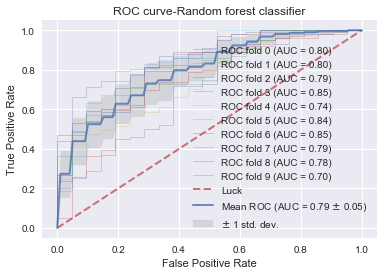

```python
cv = StratifiedKFold(n_splits=10)

tprs = []
aucs = []
mean_fpr = np.linspace(0, 1, 100)

i = 0
for train, test in cv.split(all_inputs, all_classes):
    probas_ = random_forest_classifier.fit(all_inputs[train], all_classes[train]).predict_proba(all_inputs[test])
    # Compute ROC curve and area the curve
    fpr, tpr, thresholds = roc_curve(all_classes[test], probas_[:, 1])
    tprs.append(interp(mean_fpr, fpr, tpr))
    tprs[-1][0] = 0.0
    roc_auc = auc(fpr, tpr)
    aucs.append(roc_auc)
    plt.plot(fpr, tpr, lw=1, alpha=0.3,
             label='ROC fold %d (AUC = %0.2f)' % (i, roc_auc))

    i += 1
plt.plot([0, 1], [0, 1], linestyle='--', lw=2, color='r',
         label='Luck', alpha=.8)

mean_tpr_rf = np.mean(tprs, axis=0)
mean_tpr_rf[-1] = 1.0
mean_auc_rf = auc(mean_fpr, mean_tpr_rf)
std_auc_rf = np.std(aucs)
plt.plot(mean_fpr, mean_tpr_rf, color='b',
         label=r'Mean ROC (AUC = %0.2f $\pm$ %0.2f)' % (mean_auc_rf, std_auc_rf),
         lw=2, alpha=.8)

std_tpr = np.std(tprs, axis=0)
tprs_upper = np.minimum(mean_tpr_rf + std_tpr, 1)
tprs_lower = np.maximum(mean_tpr_rf - std_tpr, 0)
plt.fill_between(mean_fpr, tprs_lower, tprs_upper, color='grey', alpha=.2,
                 label=r'$\pm$ 1 std. dev.')

plt.xlim([-0.05, 1.05])
plt.ylim([-0.05, 1.05])
plt.xlabel('False Positive Rate')
plt.ylabel('True Positive Rate')
plt.title('ROC curve-Random forest classifier')
plt.legend(loc="lower right")
```

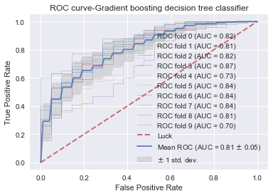

```python
cv = StratifiedKFold(n_splits=10)

tprs = []
aucs = []
mean_fpr = np.linspace(0, 1, 100)

i = 0
for train, test in cv.split(all_inputs, all_classes):
    probas_ = gradient_boosting_classifier.fit(all_inputs[train], all_classes[train]).predict_proba(all_inputs[test])
    # Compute ROC curve and area the curve
    fpr, tpr, thresholds = roc_curve(all_classes[test], probas_[:, 1])
    tprs.append(interp(mean_fpr, fpr, tpr))
    tprs[-1][0] = 0.0
    roc_auc = auc(fpr, tpr)
    aucs.append(roc_auc)
    plt.plot(fpr, tpr, lw=1, alpha=0.3,
             label='ROC fold %d (AUC = %0.2f)' % (i, roc_auc))

    i += 1
plt.plot([0, 1], [0, 1], linestyle='--', lw=2, color='r',
         label='Luck', alpha=.8)

mean_tpr_gb = np.mean(tprs, axis=0)
mean_tpr_gb[-1] = 1.0
mean_auc_gb = auc(mean_fpr, mean_tpr_gb)
std_auc_gb = np.std(aucs)
plt.plot(mean_fpr, mean_tpr_gb, color='b',
         label=r'Mean ROC (AUC = %0.2f $\pm$ %0.2f)' % (mean_auc_gb, std_auc_gb),
         lw=2, alpha=.8)

std_tpr = np.std(tprs, axis=0)
tprs_upper = np.minimum(mean_tpr_gb + std_tpr, 1)
tprs_lower = np.maximum(mean_tpr_gb - std_tpr, 0)
plt.fill_between(mean_fpr, tprs_lower, tprs_upper, color='grey', alpha=.2,
                 label=r'$\pm$ 1 std. dev.')

plt.xlim([-0.05, 1.05])
plt.ylim([-0.05, 1.05])
plt.xlabel('False Positive Rate')
plt.ylabel('True Positive Rate')
plt.title('ROC curve-Gradient boosting decision tree classifier')
plt.legend(loc="lower right")
```

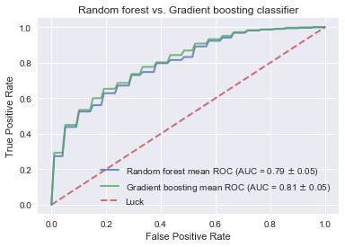

```python
mean_fpr = np.linspace(0, 1, 100)

plt.plot(mean_fpr, mean_tpr_rf, color='b',
         label=r'Random forest mean ROC (AUC = %0.2f $\pm$ %0.2f)' % (mean_auc_rf, std_auc_rf),
         lw=2, alpha=.8)

plt.plot(mean_fpr, mean_tpr_gb, color='g',
         label=r'Gradient boosting mean ROC (AUC = %0.2f $\pm$ %0.2f)' % (mean_auc_gb, std_auc_gb),
         lw=2, alpha=.8)

plt.plot([0, 1], [0, 1], linestyle='--', lw=2, color='r',
         label='Luck', alpha=.8)

plt.xlim([-0.05, 1.05])
plt.ylim([-0.05, 1.05])
plt.xlabel('False Positive Rate')
plt.ylabel('True Positive Rate')
plt.title('Random forest vs. Gradient boosting classifier')
plt.legend(loc="lower right")
```

### Conclusion

[ go back to the top ]

In this project we analyzed call log and repayment status data to build a classifier model to predict loan repayment class. After cleaning the data and removing outliers, we built 17 features from the original attributes which fall under 4 broad categories.

- Basic phone use (e.g. number of calls, number of unique contacts, number of unique area codes, mean and standard deviation of call duration).
- Active user behavior (e.g. percent of incoming/outgoing calls, percent during night/business hours ratio).
- Regularity (e.g. inter-event time between calls).
- Diversity (e.g. call entropy, contacts to interaction ratio.

and carried out exploratory analysis. We particularly observed the following correlations between attributes and the probability of repayment.

1. The probability of repayment is more for the people who have higher number of contacts, higher call entropies, higher number of calls and higher number of unique area codes. This might be interpreted that the people with larger social networks who have a more diverse domain of interactions are more likely to pay back the loan.
2. The inidividuals who have higher percent of contacts that have been saved as just one word (probably first name) have lower chances for paying back the loan. This might also be related to the size of social network a person communicates with, since people with broader networks tend to save the names more completely.
3. The probability of repayment is non monotonic for the following attributes. Thus, with increasing the value of attributes the probability first increases but after a cetrain poin will decrease. These are the variables that we discretized. for instance we can see that people who immediatley apply for loan after they sign up in Tala app and also the ones who apply much later than their sign up time both have lower probabilities of repayment.
4. 'percent_incoming'
5. 'percent_outgoing'
6. 'percent_missed'
7. 'call_duration_mean_minute'
8. 'call_duration_std_minute'
9. 'percent_nightcalls_duration'
10. 'percent_businesshours_calls_duration'
11. 'inter_event_duration_mean_minute'
12. 'inter_event_duration_std_minute'
13. 'days_from_signup_to_disbursement'

After discretizing the above variables, we learnt random forest and gardient boosting classifiers by applying randomized search method to the parameters space of the classifiers while having a cross validation approach. Gradient boosting model is slower than random forest and is thus not suitable for scalability purposes. We use area under curve (AUC) score to evaluate the eprformance of the classifiers. AUC metric is better than accuracy for this problem, especially since the class distribution is a bit skewed. We could use F1 score as well.

One ideal approach would be to define a customized evaluation metric which gives higher weights to the false positve rate error than false negative rate. In other words false alarm rate is much more critical than miss rate error. False alarm represents that an individual is predicted to repay the load while he wouldn't. On the other hand if we predict that somebody will not repay the loan but he actullay repays it, that is harmless for the company.

Since the number of features are not too many in this project, we did not perform feature selection or feature extraction here. However, for larger problems it might be useful to use these approaches to feed more relevant data to the classifiers. To do feature selection one approach is to use the correlation between phone metrics and probability of repayment as a heuristic for feature selection and include the number of features $n$ as a hyperparameter of the model.

Having more time, one direction of improving model would be to use voting classifers, for instance having an ensemble of support vector machines, logistic regression, KNN and random forest and apply majority voting to predict class.